# Transformation Methods

This notebook is to know all the transformation methods used to make the independent variables to linear relationship.

This will be helpful to get better performance for regression problems.

Transformation will be applied before prediction, But we don't know exactly which will perform better, whether original or transformed data. First use correlation matrix or pairplot to view correlation of all the variables with target variables. Then whatever are feasible to perform transformation, do it and test with both original and transformed data. Check which performs better.

Transformations are powerful tools in data analysis and modeling. They offer several benefits that can improve the performance and interpretability of statistical models, especially linear regression models. Here’s a list of key benefits:

1. Stabilizing Variance

   ```
    Benefit: Reduces heteroscedasticity (non-constant variance) in the data.
    Example: In financial data, where the variance of returns might increase with time, transformations like log or Box-Cox can stabilize the variance.
   ```

2. Improving Linearity

   ```
    Benefit: Converts non-linear relationships into linear ones, which is crucial for linear regression models.
    Example: Exponential growth patterns can be linearized using a log transformation.
   ```

3. Normalizing Distributions

   ```
    Benefit: Transforms skewed data to follow a more normal distribution, which is a common assumption for many statistical tests and models.
    Example: Sales data often has a right-skewed distribution; log or square root transformations can normalize it.
   ```

4. Reducing the Impact of Outliers

   ```
    Benefit: Diminishes the influence of extreme values or outliers, making the model more robust.
    Example: Reciprocal or log transformations can reduce the impact of large outliers.
   ```

5. Enhancing Model Performance

   ```
    Benefit: Can improve the accuracy and predictive power of models by aligning data characteristics with model assumptions.
    Example: Polynomial transformations can capture non-linear trends in the data, improving model fit.
   ```

6. Simplifying Relationships

   ```
    Benefit: Makes complex relationships easier to interpret and analyze.
    Example: Polynomial transformations can simplify the relationship between variables, making it easier to identify trends.
   ```

7. Improving Convergence

   ```
    Benefit: Helps optimization algorithms converge faster and more reliably during model training.
    Example: Well-scaled and transformed data can lead to faster convergence in gradient descent algorithms used in machine learning.
   ```

8. Facilitating Comparison

   ```
    Benefit: Standardizes the scale of data, facilitating comparison between different datasets or features.
    Example: Log transformations can standardize data across different scales, making it easier to compare growth rates.
   ```

9. Enabling the Use of Specific Models

   ```
    Benefit: Some models or techniques require data to meet certain assumptions (e.g., normality, linearity). Transformations can help meet these assumptions.
    Example: Many parametric statistical tests assume normally distributed data, which can be achieved through appropriate transformations.
   ```

10. Making Data More Interpretable

    ```
    Benefit: Transformed data can sometimes be more interpretable and meaningful, especially when dealing with rates of change or multiplicative effects.
    Example: Log transformations can make multiplicative relationships additive, simplifying interpretation.
    ```

#### Logarithm Transformation

Formula

```
    𝑦′ = log(𝑦 + 𝑐)
    where 𝑐 is a constant added to handle zero or negative values (commonly 𝑐 = 1).
```

What It Does

```
    Converts exponential growth into a linear relationship.
    Reduces the impact of large values and stabilizes variance.
```

When to Use

```
    When the target variable or features grow exponentially.
    When the data is positively skewed.
```

Use Case

```
    Example: Housing prices, where prices might increase exponentially with the size of the house or location. Log transformation can make the relationship linear.
```

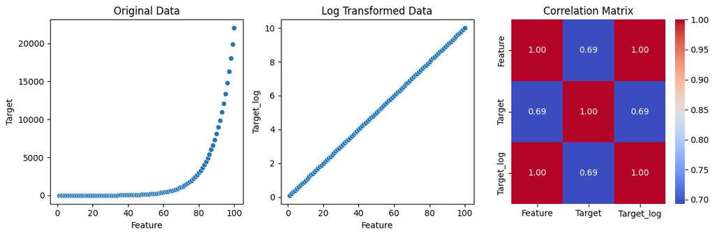

```python
import numpy as np
import pandas as pd
import matplotlib.pyplot as plt
import seaborn as sns

# Generate sample data
np.random.seed(0)
x = np.linspace(1, 100, 100)
y = np.exp(x / 10)  # Exponential relationship

# Create a DataFrame
df = pd.DataFrame({'Feature': x, 'Target': y})

# Apply log transformation to the target variable
df['Target_log'] = np.log(df['Target'])

# Plot original data
plt.figure(figsize=(12, 4))
plt.subplot(1, 3, 1)
sns.scatterplot(x='Feature', y='Target', data=df)
plt.title('Original Data')

# Plot transformed data
plt.subplot(1, 3, 2)
sns.scatterplot(x='Feature', y='Target_log', data=df)
plt.title('Log Transformed Data')

# Compute correlation matrices
corr_original = df[['Feature', 'Target']].corr()
corr_transformed = df[['Feature', 'Target_log']].corr()

# Plot heatmaps
plt.subplot(1,3,3)
sns.heatmap(df.corr(), annot=True, cmap='coolwarm', fmt='.2f')
plt.title('Correlation Matrix')
plt.tight_layout()
plt.show()
```

Formula

```
    y′ = y^^1/2
```

What It Does

```
    Reduces right skew and stabilizes variance.
    Converts data with exponential or quadratic growth into a more linear form.
```

When to Use

```
    When the target or features are right-skewed.
    When variance increases with the magnitude of the data.
```

Use Case

```
    Example: Data on number of events per month; square root transformation can make it more normally distributed.
```

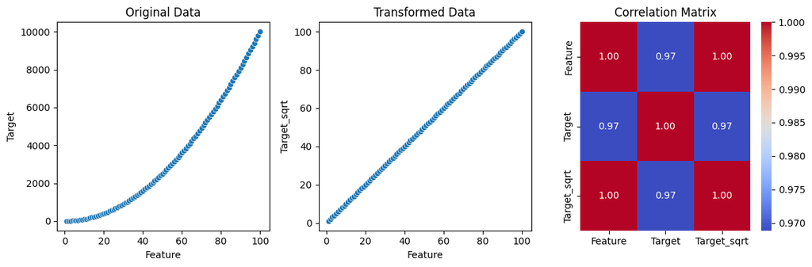

```python
import numpy as np
import pandas as pd
import matplotlib.pyplot as plt
import seaborn as sns
from scipy.stats import boxcox, yeojohnson

# Generate sample data
np.random.seed(0)
x = np.linspace(1, 100, 100)
y = x**2  # Square root relationship

# Create a DataFrame
df = pd.DataFrame({'Feature': x, 'Target': y})

# Apply square root transformation
df['Target_sqrt'] = np.sqrt(df['Target'])

# Plot original data
plt.figure(figsize=(12, 4))
plt.subplot(1, 3, 1)
sns.scatterplot(x='Feature', y='Target', data=df)
plt.title('Original Data')

# Plot transformed data
plt.subplot(1, 3, 2)
sns.scatterplot(x='Feature', y='Target_sqrt', data=df)
plt.title('Transformed Data')

# Compute correlation matrices
corr_original = df[['Feature', 'Target']].corr()
corr_transformed = df[['Feature', 'Target_sqrt']].corr()

plt.subplot(1,3,3)
sns.heatmap(df.corr(), annot=True, cmap='coolwarm', fmt='.2f')
plt.title('Correlation Matrix')
plt.tight_layout()
plt.show()
```

#### Reciprocal Transformation

Formula

```
    𝑦′ = 1 / 𝑦+𝑐
    where c is a small constant to avoid division by zero.
```

What It Does

```
    Converts data with a hyperbolic relationship into a more linear relationship.
    Reduces the impact of very large values and can make relationships more linear.
```

When to Use

```
    When the target or features have a rapid decrease with an increase in values.
    When dealing with data that follows a hyperbolic pattern.
```

Use Case

```
    Example: Data on the speed of a process that rapidly increases as the input increases. Reciprocal transformation can linearize such relationships.
```

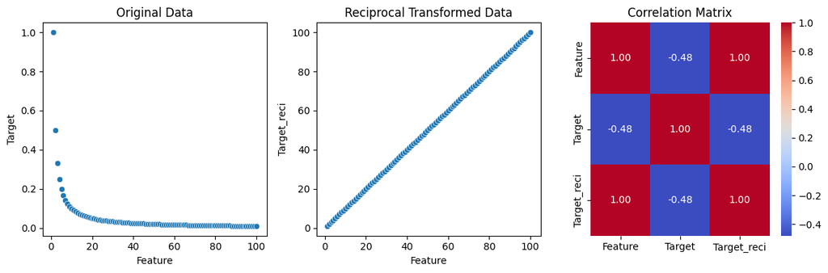

```python
import numpy as np
import pandas as pd
import matplotlib.pyplot as plt
import seaborn as sns

# Generate sample data
np.random.seed(0)
x = np.linspace(1, 100, 100)
y = 1 / (x)  # Reciprocal relationship

# Create a DataFrame
df = pd.DataFrame({'Feature': x, 'Target': y})

# Apply reciprocal transformation
df['Target_reci'] = 1 / (df['Target'])  # Adding a small constant to avoid division by zero

# Plot original data
plt.figure(figsize=(12, 4))
plt.subplot(1, 3, 1)
sns.scatterplot(x='Feature', y='Target', data=df)
plt.title('Original Data')

# Plot transformed data
plt.subplot(1, 3, 2)
sns.scatterplot(x='Feature', y='Target_reci', data=df)
plt.title('Reciprocal Transformed Data')

# Compute correlation matrices
corr_original = df[['Feature', 'Target']].corr()
corr_transformed = df[['Feature', 'Target_reci']].corr()

plt.subplot(1,3,3)
sns.heatmap(df.corr(), annot=True, cmap='coolwarm', fmt='.2f')
plt.title('Correlation Matrix')
plt.tight_layout()
plt.show()
```

#### Polynomial Transformation

Formula

```
    For degree 𝑑, the transformation adds polynomial terms: 𝑋′=[1,𝑥,𝑥^2,𝑥^3,…,𝑥^𝑑]
```

What It Does

```
    Captures non-linear relationships by adding polynomial terms to the feature.
    Allows linear models to fit non-linear relationships by increasing the feature space.
```

When to Use

```
    When you need to capture quadratic or higher-order relationships in the data.
```

Use Case

```
    Example: Predicting housing prices where the relationship between the size of the house and the price might be quadratic.
```

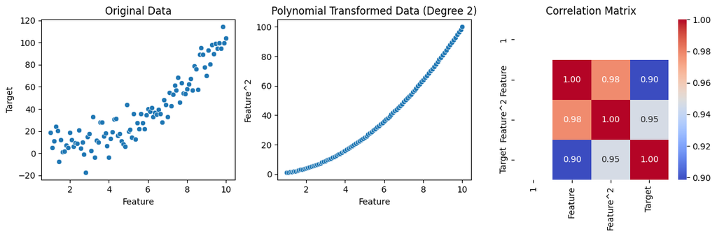

```python
import numpy as np
import pandas as pd
import matplotlib.pyplot as plt
import seaborn as sns
from sklearn.preprocessing import PolynomialFeatures

# Generate sample data
np.random.seed(0)
x = np.linspace(1, 10, 100)
y = x**2 + np.random.normal(0, 10, size=x.shape)  # Quadratic relationship

# Create a DataFrame
df = pd.DataFrame({'Feature': x, 'Target': y})

# Apply polynomial transformation (degree 2)
poly = PolynomialFeatures(degree=2)
X_poly = poly.fit_transform(df[['Feature']])
df_poly = pd.DataFrame(X_poly, columns=poly.get_feature_names_out())
df_poly['Target'] = df['Target']

# Plot original data
plt.figure(figsize=(12, 4))
plt.subplot(1, 3, 1)
sns.scatterplot(x='Feature', y='Target', data=df)
plt.title('Original Data')

# Plot transformed data
plt.subplot(1, 3, 2)
sns.scatterplot(x='Feature', y='Feature^2', data=df_poly)
plt.title('Polynomial Transformed Data (Degree 2)')

# Compute correlation matrices
corr_original = df[['Feature', 'Target']].corr()
corr_transformed = df_poly[['Feature', 'Feature^2', 'Target']].corr()

plt.subplot(1,3,3)
sns.heatmap(df_poly.corr(), annot=True, cmap='coolwarm', fmt='.2f')
plt.title('Correlation Matrix')
plt.tight_layout()
plt.show()
```

#### Boxcox Transformation

Formula

```
    𝑦′= (𝑦^𝜆−1) / 𝜆
    where 𝜆 is the parameter that maximizes the log-likelihood function.
```

What It Does

```
    Stabilizes variance and makes data more normally distributed.
    Requires positive data values.
```

When to Use

```
    When the target variable is positively skewed.
    When variance increases with the magnitude of the data.
```

Use Case

```
    Example: Financial data that is highly skewed. Box-Cox transformation can help normalize the data.
```

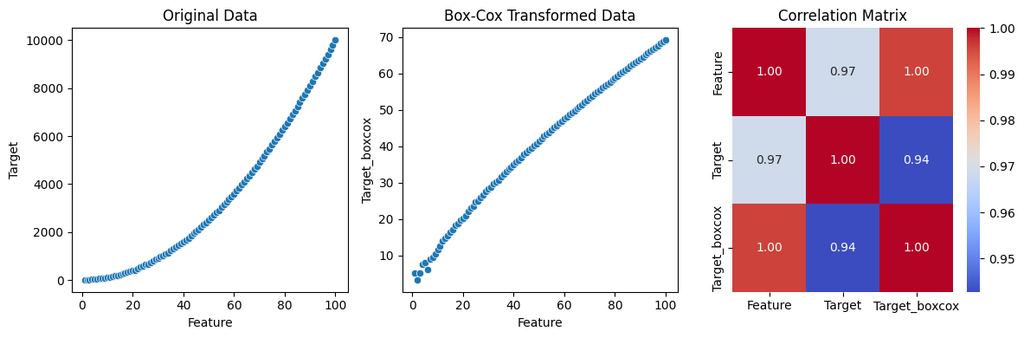

```python
import numpy as np
import pandas as pd
import matplotlib.pyplot as plt
import seaborn as sns
from scipy.stats import boxcox

# Generate sample data
np.random.seed(0)
x = np.linspace(1, 100, 100)
y = x**2 + np.random.normal(0, 10, size=x.shape)  # Quadratic relationship

# Create a DataFrame
df = pd.DataFrame({'Feature': x, 'Target': y})

# Apply Box-Cox transformation
df['Target_boxcox'], _ = boxcox(df['Target'] + 1)  # Adding 1 to avoid zero values

# Plot original data
plt.figure(figsize=(12, 4))
plt.subplot(1, 3, 1)
sns.scatterplot(x='Feature', y='Target', data=df)
plt.title('Original Data')

# Plot transformed data
plt.subplot(1, 3, 2)
sns.scatterplot(x='Feature', y='Target_boxcox', data=df)
plt.title('Box-Cox Transformed Data')

# Compute correlation matrices
corr_original = df[['Feature', 'Target']].corr()
corr_transformed = df[['Feature', 'Target_boxcox']].corr()

plt.subplot(1,3,3)
sns.heatmap(df.corr(), annot=True, cmap='coolwarm', fmt='.2f')
plt.title('Correlation Matrix')
plt.tight_layout()
plt.show()
```

#### Yeo Johnson Transformation

Formula

```
    For y>0: 𝑦′=((𝑦+1)^𝜆 − 1) / 𝜆
    For y≤0: 𝑦′=((𝑦+1)^(2−𝜆) − 1) / (2−𝜆)
    where 𝜆 is the parameter that maximizes the log-likelihood function.
```

What It Does

```
    Stabilizes variance and makes data more normally distributed.
    Handles both positive and negative values.
```

When to Use

```
    When the target variable contains both positive and negative values.
    When you need a robust transformation for non-normal data distributions.
```

Use Case

```
    Example: Data with both positive and negative values, such as financial returns or residuals from a model.
```

##### Example 1

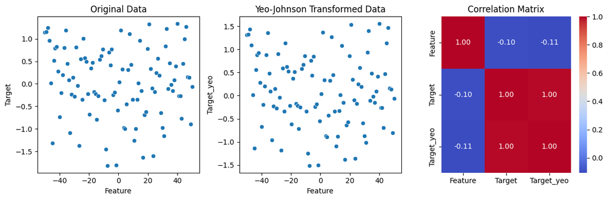

```python
import numpy as np
import pandas as pd
import matplotlib.pyplot as plt
import seaborn as sns
from scipy.stats import yeojohnson

# Generate sample data
np.random.seed(0)
x = np.linspace(-50, 50, 100)
y = np.sin(x) + np.random.normal(0, 0.5, size=x.shape)  # Non-linear relationship

# Create a DataFrame
df = pd.DataFrame({'Feature': x, 'Target': y})

# Apply Yeo-Johnson transformation
df['Target_yeo'], _ = yeojohnson(df['Target'])

# Plot original data
plt.figure(figsize=(12, 4))
plt.subplot(1, 3, 1)
sns.scatterplot(x='Feature', y='Target', data=df)
plt.title('Original Data')

# Plot transformed data
plt.subplot(1, 3, 2)
sns.scatterplot(x='Feature', y='Target_yeo', data=df)
plt.title('Yeo-Johnson Transformed Data')

# Compute correlation matrices
corr_original = df[['Feature', 'Target']].corr()
corr_transformed = df[['Feature', 'Target_yeo']].corr()

plt.subplot(1,3,3)
sns.heatmap(df.corr(), annot=True, cmap='coolwarm', fmt='.2f')
plt.title('Correlation Matrix')
plt.tight_layout()
plt.show()
```

##### Example 2

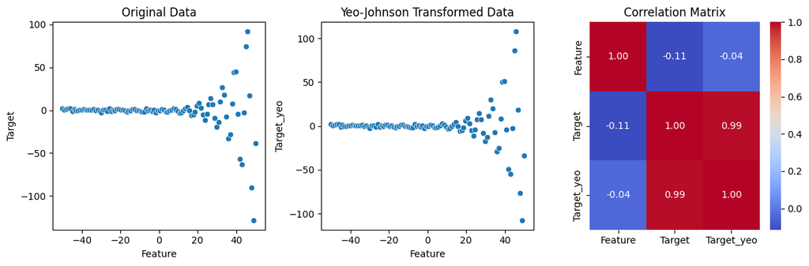

```python
import numpy as np
import pandas as pd
import matplotlib.pyplot as plt
import seaborn as sns
from scipy.stats import yeojohnson

# Generate sample data
np.random.seed(0)
x = np.linspace(-50, 50, 100)  # Feature with both negative and positive values
y = np.sin(x) * np.exp(0.1 * x) + np.random.normal(0, 1, size=x.shape)  # Non-linear relationship

# Create a DataFrame
df = pd.DataFrame({'Feature': x, 'Target': y})

# Apply Yeo-Johnson transformation
df['Target_yeo'], _ = yeojohnson(df['Target'])

# Plot original data
plt.figure(figsize=(12, 4))
plt.subplot(1, 3, 1)
sns.scatterplot(x='Feature', y='Target', data=df)
plt.title('Original Data')

# Plot transformed data
plt.subplot(1, 3, 2)
sns.scatterplot(x='Feature', y='Target_yeo', data=df)
plt.title('Yeo-Johnson Transformed Data')

# Compute correlation matrices
corr_original = df[['Feature', 'Target']].corr()
corr_transformed = df[['Feature', 'Target_yeo']].corr()

plt.subplot(1,3,3)
sns.heatmap(df.corr(), annot=True, cmap='coolwarm', fmt='.2f')
plt.title('Correlation Matrix')
plt.tight_layout()
plt.show()
```

Summary

```
    Log Transformation: Converts exponential growth into linear relationships, useful for right-skewed data.
    Square Root Transformation: Reduces right skew, useful when variance increases with the magnitude.
    Reciprocal Transformation: Useful for hyperbolic relationships and rapid decreases.
    Polynomial Transformation: Captures non-linear relationships by adding polynomial terms.
    Box-Cox Transformation: Normalizes positive data and stabilizes variance.
    Yeo-Johnson Transformation: General-purpose transformation for stabilizing variance and normalizing data with both positive and negative values.
```

### Power Transformer

Just for testing purpose

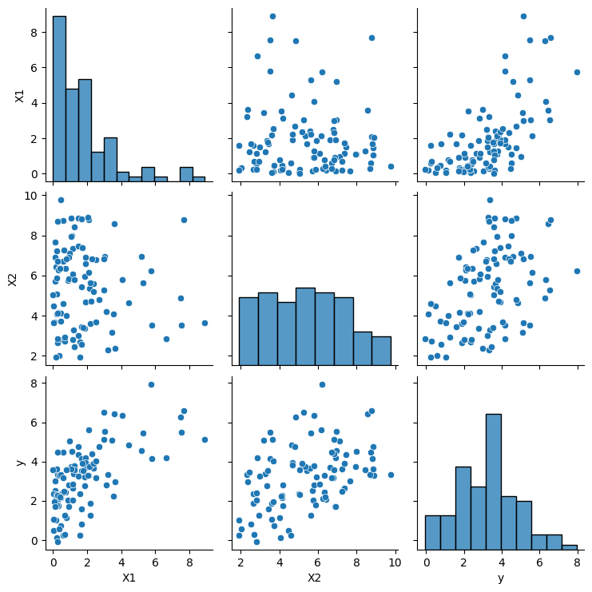

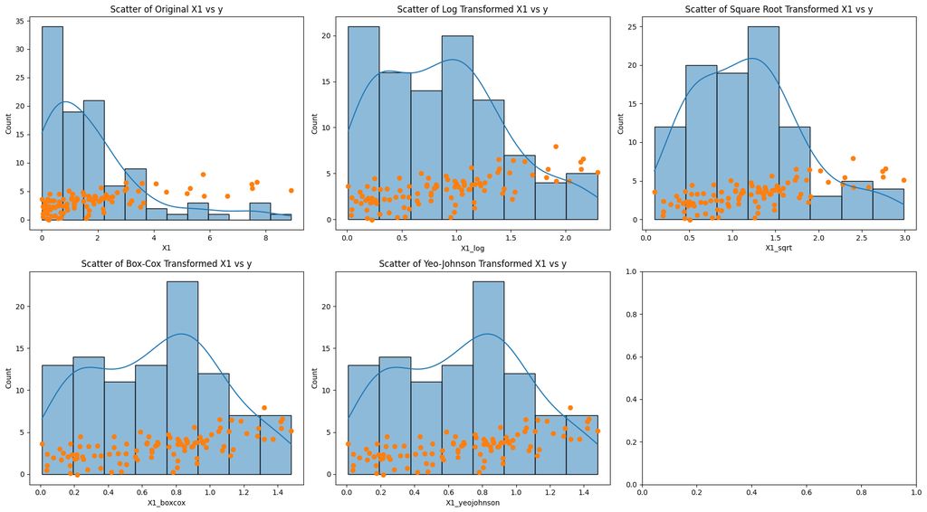

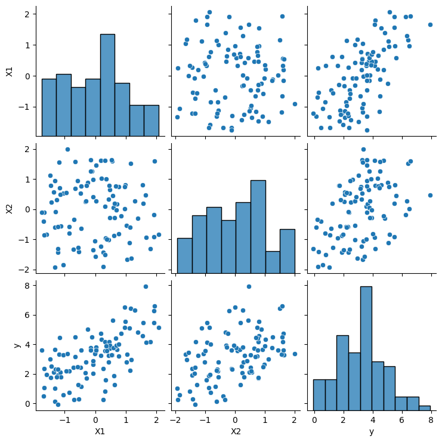

```python
import numpy as np
import pandas as pd
import matplotlib.pyplot as plt
import seaborn as sns
from sklearn.preprocessing import PowerTransformer
from scipy.stats import boxcox, yeojohnson

# Generate synthetic data
np.random.seed(0)
X1 = np.random.exponential(scale=2, size=100)
X2 = np.random.normal(loc=5, scale=2, size=100)
y = 2 * np.log(X1 + 1) + 0.3 * X2 + np.random.normal(size=100)

# Combine into a DataFrame
df = pd.DataFrame({'X1': X1, 'X2': X2, 'y': y})

# Visualize original data
sns.pairplot(df)
plt.show()

# Function to apply transformations and plot results
def apply_transformations(df, col):
    fig, axes = plt.subplots(2, 3, figsize=(18, 10))

    sns.histplot(df[col], kde=True, ax=axes[0, 0]).set_title(f'Original {col}')
    axes[0, 0].scatter(df[col], df['y'])
    axes[0, 0].set_title(f'Scatter of Original {col} vs y')

    df[f'{col}_log'] = np.log(df[col] + 1)
    sns.histplot(df[f'{col}_log'], kde=True, ax=axes[0, 1]).set_title(f'Log Transformed {col}')
    axes[0, 1].scatter(df[f'{col}_log'], df['y'])
    axes[0, 1].set_title(f'Scatter of Log Transformed {col} vs y')

    df[f'{col}_sqrt'] = np.sqrt(df[col])
    sns.histplot(df[f'{col}_sqrt'], kde=True, ax=axes[0, 2]).set_title(f'Square Root Transformed {col}')
    axes[0, 2].scatter(df[f'{col}_sqrt'], df['y'])
    axes[0, 2].set_title(f'Scatter of Square Root Transformed {col} vs y')

    df[f'{col}_boxcox'], _ = boxcox(df[col] + 1)
    sns.histplot(df[f'{col}_boxcox'], kde=True, ax=axes[1, 0]).set_title(f'Box-Cox Transformed {col}')
    axes[1, 0].scatter(df[f'{col}_boxcox'], df['y'])
    axes[1, 0].set_title(f'Scatter of Box-Cox Transformed {col} vs y')

    df[f'{col}_yeojohnson'], _ = yeojohnson(df[col])
    sns.histplot(df[f'{col}_yeojohnson'], kde=True, ax=axes[1, 1]).set_title(f'Yeo-Johnson Transformed {col}')
    axes[1, 1].scatter(df[f'{col}_yeojohnson'], df['y'])
    axes[1, 1].set_title(f'Scatter of Yeo-Johnson Transformed {col} vs y')

    plt.tight_layout()
    plt.show()

# Apply transformations to X1
apply_transformations(df, 'X1')

# Apply PowerTransformer to all columns (except target)
pt = PowerTransformer(method='yeo-johnson')
transformed_data = pt.fit_transform(df[['X1', 'X2']])
df_transformed = pd.DataFrame(transformed_data, columns=['X1', 'X2'])
df_transformed['y'] = df['y']

# Visualize transformed data
sns.pairplot(df_transformed)
plt.show()
```